# Bootstrap Regression to predict glucose levels

Sebastian Ross

2026-09-12

# 1 Introduction

We analyse a dataset of 5,110 patients to study what factors are associated with average glucose level (`avg_glucose_level`, mg/dL).Elevated glucose is a well-established risk factor for stroke, cardiovascular disease, and diabetes; understanding which clinical and demographic variables co-move with glucose may help identify patients who would benefit from earlier screening and lifestyle intervention.

The data are from the Kaggle *Stroke Prediction Dataset* (https://www.kaggle.com/datasets/fedesoriano/stroke-prediction-dataset) and contain 12 variables: `id`: a unique identification number `gender` The gender of the person male, female or other `age` the age of the patient `hypertension` if the patient has hypertension `heart_disease` if the patient has heart disease `ever_married` if the person is has been married or not `work_type` The type of work that they do children, government job, never worked, private or self employed. `Residence_type` The type of residence a person lives in Rural or Urban `avg_glucose_level` The avrage glucose level of a patient `bmi` The BMI of a given patient `smoking_status` If a person smokes, never smoked, formaly smoked, or it is unknown. `stroke` If the person has ever had a stroke before

Our goal is to figure out which of our factors are associated with average glucose level and which are useful predictors.

```r
url <- "https://raw.githubusercontent.com/Kingsoul42/STA-321/main/dataset/healthcare-dataset-stroke-data.csv"
stroke_predictions <- read.csv(url, header = TRUE)
```

# 2 Exploratory Data Analysis

`ever_married`, `work_type`, `Residence_type`,`avg_glucose_level`, `bmi`, `smoking_status`, and `stroke` are our character variables. We will be looking at the different variables looking for sparcety and know what we should do with those values. We will be looking at these different variables via bar graph to judge sparsity. We will also be looking at any of the variables to see if they make sense to be included in the model as predictor or not.

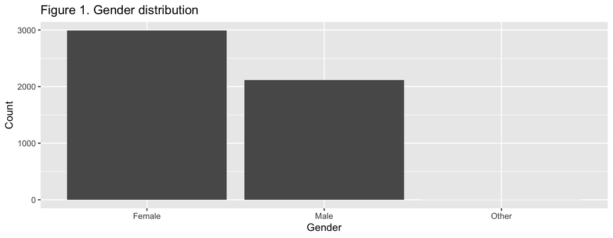

```r
df <- stroke_predictions[, c("gender","hypertension","heart_disease",
                             "ever_married","work_type","Residence_type",
                             "smoking_status","stroke")]

ggplot(df, aes(x = gender)) + geom_bar() +
  labs(title = "Figure 1. Gender distribution", x = "Gender", y = "Count")
```

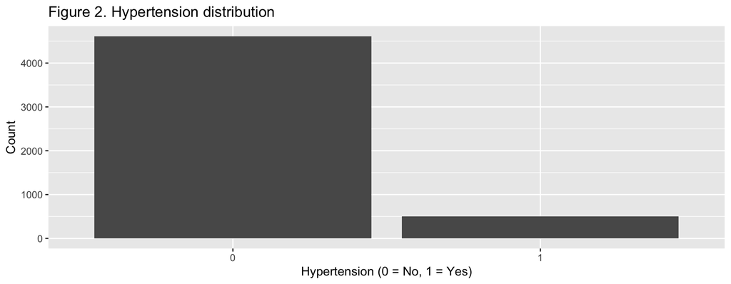

```r
ggplot(df, aes(x = factor(hypertension))) + geom_bar() +
  labs(title = "Figure 2. Hypertension distribution",
       x = "Hypertension (0 = No, 1 = Yes)", y = "Count")
```

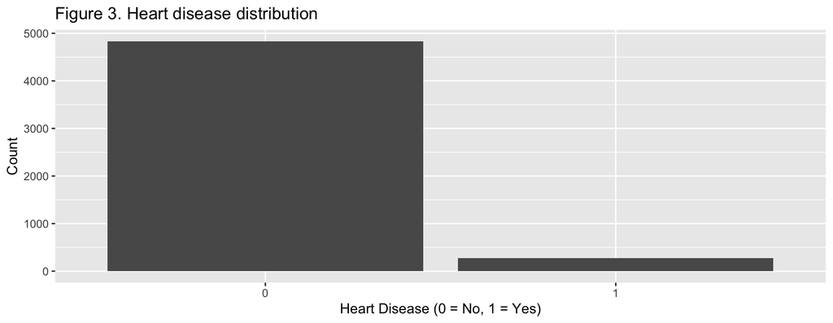

```r
ggplot(df, aes(x = factor(heart_disease))) + geom_bar() +
  labs(title = "Figure 3. Heart disease distribution",
       x = "Heart Disease (0 = No, 1 = Yes)", y = "Count")
```

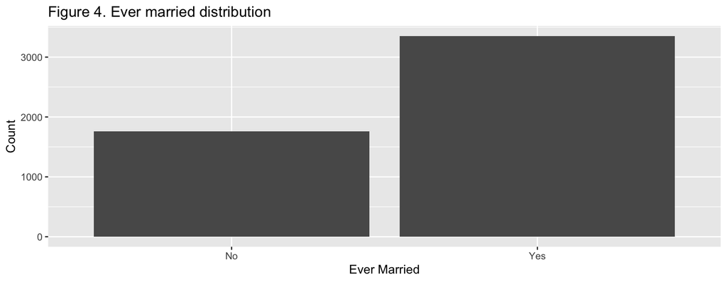

```r
ggplot(df, aes(x = ever_married)) + geom_bar() +
  labs(title = "Figure 4. Ever married distribution",
       x = "Ever Married", y = "Count")
```

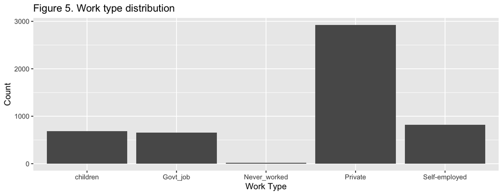

```r
ggplot(df, aes(x = work_type)) + geom_bar() +
  labs(title = "Figure 5. Work type distribution",
       x = "Work Type", y = "Count")
```

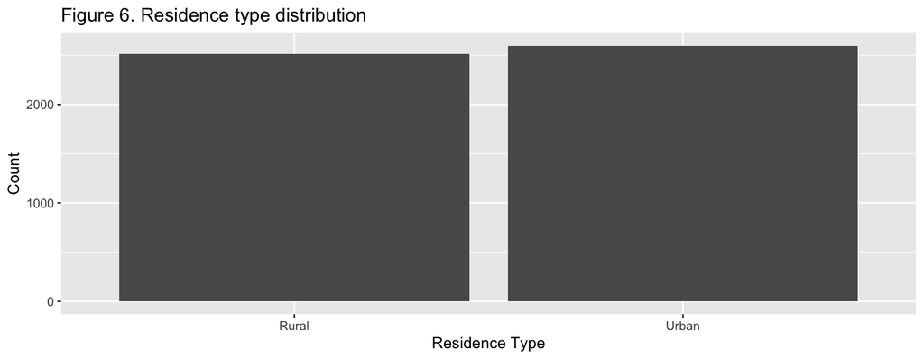

```r
ggplot(df, aes(x = Residence_type)) + geom_bar() +
  labs(title = "Figure 6. Residence type distribution",
       x = "Residence Type", y = "Count")
```

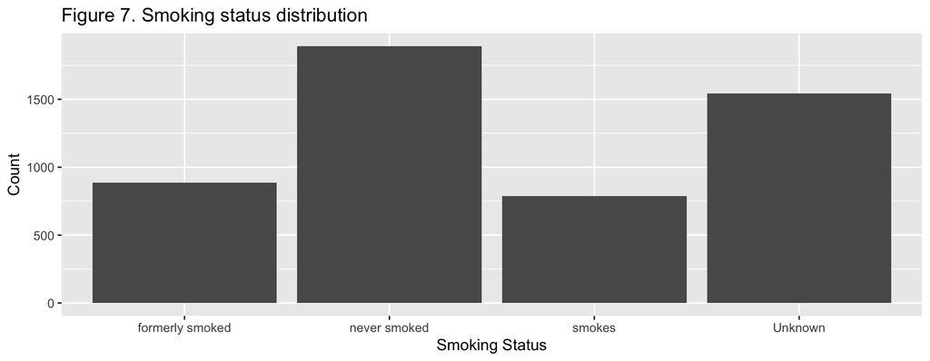

```r
ggplot(df, aes(x = smoking_status)) + geom_bar() +
  labs(title = "Figure 7. Smoking status distribution",
       x = "Smoking Status", y = "Count")
```

```r
stroke_predictions$id  <- NULL
stroke_predictions$bmi <- suppressWarnings(as.numeric(stroke_predictions$bmi))

stroke_predictions <- stroke_predictions[stroke_predictions$gender != "Other", ]

cat_vars <- c("gender", "ever_married", "work_type",
              "Residence_type", "smoking_status")
stroke_predictions[cat_vars] <- lapply(stroke_predictions[cat_vars], factor)

imp <- mice(stroke_predictions, m = 5, seed = 1, printFlag = FALSE)
stroke_predictions_imp <- complete(imp, 1)
stroke_predictions_imp$hypertension <- factor(stroke_predictions_imp$hypertension)
stroke_predictions_imp$heart_disease <- factor(stroke_predictions_imp$heart_disease)
stroke_predictions_imp$stroke <- factor(stroke_predictions_imp$stroke)
```

# 3 Model Building

```r
full_model <- lm(
  avg_glucose_level ~ age + hypertension + heart_disease +
                      bmi + gender + ever_married + work_type+ Residence_type + smoking_status,
  data = stroke_predictions_imp
)

backward_step <- step(full_model, direction = "backward", trace = FALSE)

null_model <- lm(avg_glucose_level ~ 1, data = stroke_predictions_imp)
forward_step <- step(null_model, scope = formula(full_model),
                     direction = "forward", trace = FALSE)
summary(forward_step)
```

```
FALSE
FALSE Call:
FALSE lm(formula = avg_glucose_level ~ age + hypertension + heart_disease +
FALSE     bmi + work_type + gender, data = stroke_predictions_imp)
FALSE
FALSE Residuals:
FALSE     Min      1Q  Median      3Q     Max
FALSE -108.19  -28.06  -11.13   14.39  164.23
FALSE
FALSE Coefficients:
FALSE                         Estimate Std. Error t value Pr(>|t|)
FALSE (Intercept)             73.92372    2.47920  29.818  < 2e-16 ***
FALSE age                      0.44978    0.03870  11.621  < 2e-16 ***
FALSE hypertension1           14.69145    2.13341   6.886 6.42e-12 ***
FALSE heart_disease1          18.96898    2.79022   6.798 1.18e-11 ***
FALSE bmi                      0.76255    0.08686   8.779  < 2e-16 ***
FALSE work_typeGovt_job      -16.62228    2.98743  -5.564 2.77e-08 ***
FALSE work_typeNever_worked   -6.64240    9.34325  -0.711  0.47716
FALSE work_typePrivate       -14.77788    2.46808  -5.988 2.28e-09 ***
FALSE work_typeSelf-employed -17.40443    3.07503  -5.660 1.60e-08 ***
FALSE genderMale               4.00696    1.23430   3.246  0.00118 **
FALSE ---
FALSE Signif. codes:  0 '***' 0.001 '**' 0.01 '*' 0.05 '.' 0.1 ' ' 1
FALSE
FALSE Residual standard error: 43.05 on 5099 degrees of freedom
FALSE Multiple R-squared:  0.09778, Adjusted R-squared:  0.09619
FALSE F-statistic:  61.4 on 9 and 5099 DF,  p-value: < 2.2e-16
```

```r
summary(backward_step)
```

```
FALSE
FALSE Call:
FALSE lm(formula = avg_glucose_level ~ age + hypertension + heart_disease +
FALSE     bmi + gender + work_type, data = stroke_predictions_imp)
FALSE
FALSE Residuals:
FALSE     Min      1Q  Median      3Q     Max
FALSE -108.19  -28.06  -11.13   14.39  164.23
FALSE
FALSE Coefficients:
FALSE                         Estimate Std. Error t value Pr(>|t|)
FALSE (Intercept)             73.92372    2.47920  29.818  < 2e-16 ***
FALSE age                      0.44978    0.03870  11.621  < 2e-16 ***
FALSE hypertension1           14.69145    2.13341   6.886 6.42e-12 ***
FALSE heart_disease1          18.96898    2.79022   6.798 1.18e-11 ***
FALSE bmi                      0.76255    0.08686   8.779  < 2e-16 ***
FALSE genderMale               4.00696    1.23430   3.246  0.00118 **
FALSE work_typeGovt_job      -16.62228    2.98743  -5.564 2.77e-08 ***
FALSE work_typeNever_worked   -6.64240    9.34325  -0.711  0.47716
FALSE work_typePrivate       -14.77788    2.46808  -5.988 2.28e-09 ***
FALSE work_typeSelf-employed -17.40443    3.07503  -5.660 1.60e-08 ***
FALSE ---
FALSE Signif. codes:  0 '***' 0.001 '**' 0.01 '*' 0.05 '.' 0.1 ' ' 1
FALSE
FALSE Residual standard error: 43.05 on 5099 degrees of freedom
FALSE Multiple R-squared:  0.09778, Adjusted R-squared:  0.09619
FALSE F-statistic:  61.4 on 9 and 5099 DF,  p-value: < 2.2e-16
```

Both step wise procedures converge on the same reduced model showing that it is the preferred reduced model and that it is robust.

# 4 4. Model Diagnostics

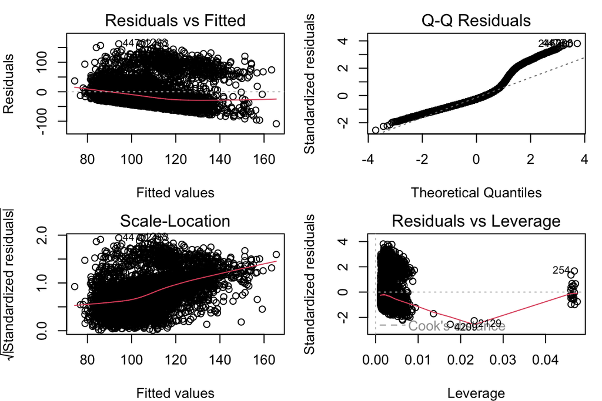

```r
#model assumptions
par(mfrow = c(2,2), mar = c(4, 4, 2, 1))
plot(full_model)
```

The residual plots show a non constant variance showing a distinct pattern and clustering. We also see the residuals are coming off the dashed line in the Q-Q plot. We also see that there are a couple of highly influental points that could be skewing the data.

# 5 Box–Cox Transformation

In this section we will be seeing if transformations might help solve so of our issues we see in the full model. For this we will do a box-cox transformation on our models. We will look at a graph and look to see what is a good value for the lamda we will use to transform the models.

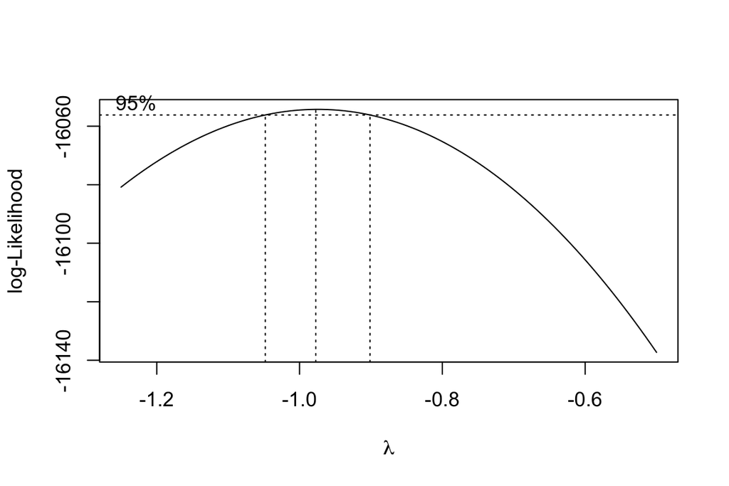

```r
boxcox(full_model, lambda = seq(-1.25, -0.5, by = 0.05))
```

From the graph we see that **λ = −0.9** seems to be a good value for lamda with it being in the interval and is a convinent value to use.

$$Y^{*} \;=\; \frac{Y^{-0.9} - 1}{-0.9}.$$

```r
lambda <- -0.9
bc <- function(y) (y^lambda - 1) / lambda

stroke_predictions_imp$glucose_bc <- bc(stroke_predictions_imp$avg_glucose_level)

full_model_bc <- lm(
  glucose_bc ~ age + hypertension + heart_disease +
               bmi + gender + ever_married + work_type,
  data = stroke_predictions_imp
)

backward_bc <- step(full_model_bc, direction = "backward", trace = FALSE)
summary(backward_bc)
```

```
FALSE
FALSE Call:
FALSE lm(formula = glucose_bc ~ age + hypertension + heart_disease +
FALSE     bmi + gender + work_type, data = stroke_predictions_imp)
FALSE
FALSE Residuals:
FALSE        Min         1Q     Median         3Q        Max
FALSE -0.0161485 -0.0035159 -0.0002091  0.0034993  0.0126271
FALSE
FALSE Coefficients:
FALSE                          Estimate Std. Error  t value Pr(>|t|)
FALSE (Intercept)             1.090e+00  2.996e-04 3636.737  < 2e-16 ***
FALSE age                     3.864e-05  4.677e-06    8.262  < 2e-16 ***
FALSE hypertension1           1.363e-03  2.578e-04    5.285 1.31e-07 ***
FALSE heart_disease1          1.781e-03  3.372e-04    5.282 1.33e-07 ***
FALSE bmi                     7.158e-05  1.050e-05    6.820 1.02e-11 ***
FALSE genderMale              4.304e-04  1.492e-04    2.885  0.00393 **
FALSE work_typeGovt_job      -1.588e-03  3.610e-04   -4.398 1.12e-05 ***
FALSE work_typeNever_worked  -5.913e-04  1.129e-03   -0.524  0.60049
FALSE work_typePrivate       -1.354e-03  2.982e-04   -4.539 5.79e-06 ***
FALSE work_typeSelf-employed -1.641e-03  3.716e-04   -4.417 1.02e-05 ***
FALSE ---
FALSE Signif. codes:  0 '***' 0.001 '**' 0.01 '*' 0.05 '.' 0.1 ' ' 1
FALSE
FALSE Residual standard error: 0.005202 on 5099 degrees of freedom
FALSE Multiple R-squared:  0.05644, Adjusted R-squared:  0.05477
FALSE F-statistic: 33.89 on 9 and 5099 DF,  p-value: < 2.2e-16
```

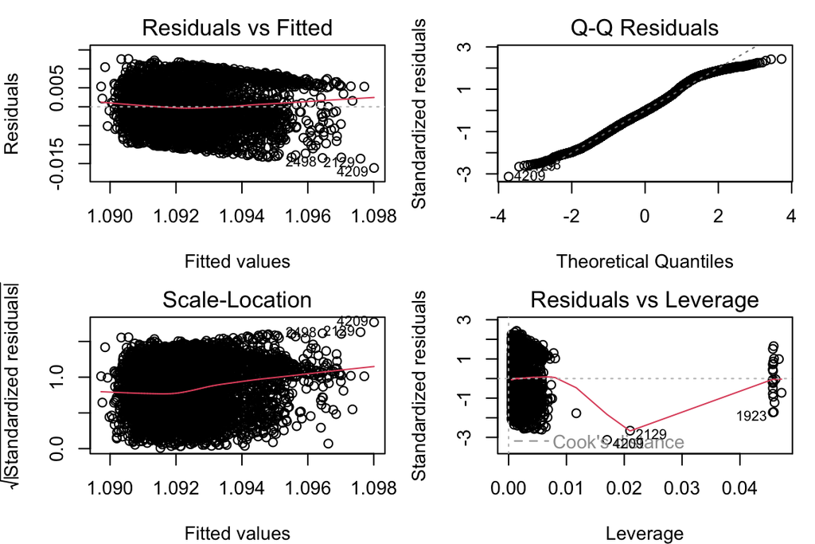

```r
#model assumptions
par(mfrow = c(2,2), mar = c(4, 4, 2, 1))
plot(backward_bc)
```

We see most of the same issues as before with a distinct pattern in the top left. A better tail in the Q-Q plot but still shows that it is nor normal with it straying from the dashed line. We also still see some influental points that could be influencing our results.

# 6 Model Diagnostics and Goodness-of-Fit

Here we will be looking for multicollinearity, if our residuals are normal as well as the goodness of fit for the model. We will be using vif function to look at the multicollinearity. We will be using Shapiro Wilks test and a Q-Q plot to look for normality of the residuals in our model. We will look at goodness of fit to select the best model for us to use. ## Multicollinearity (VIF)

```r
#check for Multicollinearity
vif(full_model_bc)
```

```
FALSE                   GVIF Df GVIF^(1/(2*Df))
FALSE age           2.763263  1        1.662306
FALSE hypertension  1.104720  1        1.051057
FALSE heart_disease 1.102022  1        1.049773
FALSE bmi           1.292809  1        1.137017
FALSE gender        1.018875  1        1.009393
FALSE ever_married  1.983091  1        1.408223
FALSE work_type     2.218063  4        1.104706
```

We see that there is little to no multidisciplinary in our model to worry about.. With all of the adjusted values being below 2 being the value for little to no concern ## Normality of Residuals

```r
# normality check
res <- residuals(backward_bc)
shapiro.test(res[seq_len(min(5000, length(res)))])
```

```
FALSE
FALSE   Shapiro-Wilk normality test
FALSE
FALSE data:  res[seq_len(min(5000, length(res)))]
FALSE W = 0.99094, p-value < 2.2e-16
```

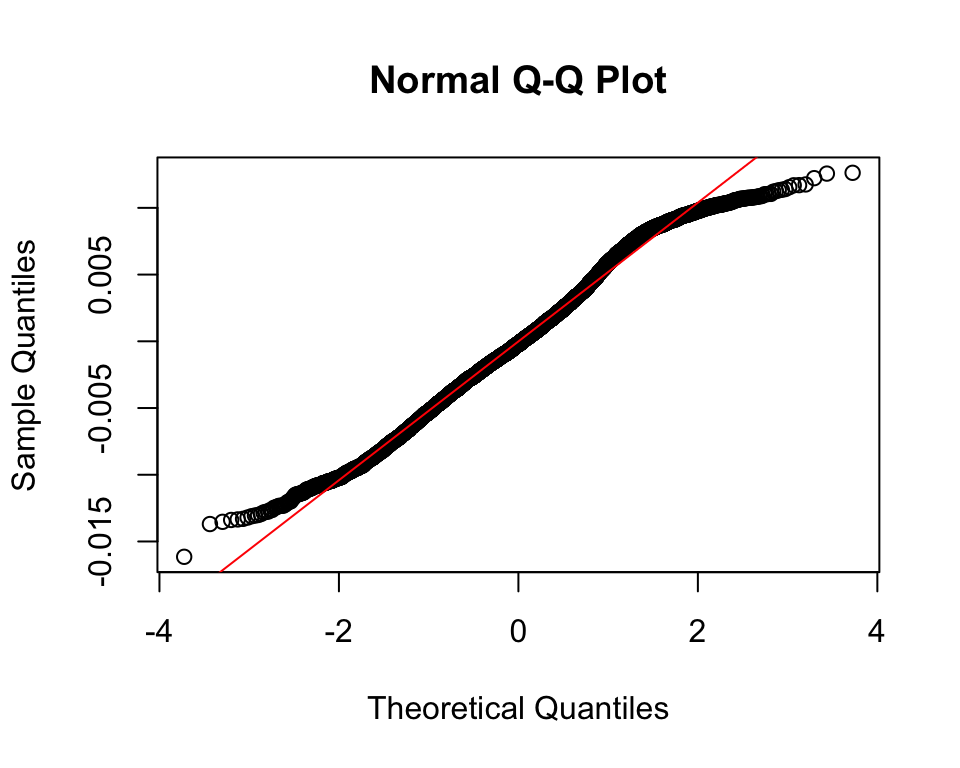

```r
qqnorm(res); qqline(res, col = "red")
```

From this we still see with the shapiro wilks test and the Q-Q plot that the residuals for this model are not normally distributed. ## 6.3 Goodness-of-Fit Comparison

```r
select <- function(m) {
  e     <- residuals(m)
  n0    <- length(e)
  dfr   <- df.residual(m)
  sigma <- summary(m)$sigma
  SSE   <- dfr * sigma^2
  R.sq  <- summary(m)$r.squared
  R.adj <- summary(m)$adj.r.squared
  MSE   <- sigma^2
  Cp    <- (SSE / MSE) - (n0 - 2 * (n0 - dfr))
  AIC   <- n0*log(SSE) - n0*log(n0) + 2 * (n0 - dfr)
  SBC   <- n0*log(SSE) - n0*log(n0) + log(n0) * (n0 - dfr)
  X     <- model.matrix(m)
  H     <- X %*% solve(t(X) %*% X) %*% t(X)
  d     <- e / (1 - diag(H))
  PRESS <- sum(d^2)
  data.frame(SSE = SSE, R.sq = R.sq, R.adj = R.adj,
             Cp = Cp, AIC = AIC, SBC = SBC, PRESS = PRESS)
}
gof <- rbind(select(full_model), select(full_model_bc), select(backward_bc))
row.names(gof) <- c("Full (raw)", "Full (Box–Cox)", "Reduced (Box–Cox)")
kable(gof, digits = 4,
      caption = "Table 1. Goodness-of-fit measures for candidate models")
```

Table 1. Goodness-of-fit measures for candidate models

|  | SSE | R.sq | R.adj | Cp | AIC | SBC | PRESS |
| --- | --- | --- | --- | --- | --- | --- | --- |
| Full (raw) | 9445634.529 | 0.0983 | 0.0958 | 15 | 38461.45 | 38559.53 | 9507937.7996 |
| Full (Box–Cox) | 0.138 | 0.0565 | 0.0546 | 11 | -53721.09 | -53649.16 | 0.1386 |
| Reduced (Box–Cox) | 0.138 | 0.0564 | 0.0548 | 10 | -53722.76 | -53657.37 | 0.1386 |

Between these models we should be using the transformed reduced model. We see that they are very close in SSE and PRESS but better in the AIC, SBC and adj.
$$R^2$$
values. even though the transformed model it has higher dimensionality making it hard to understand as well as with the different scales of the modes making it not as interpretative. # Final Model For the final model decision we will bw using the reduced model. here we will also look to understand the difference in scale of the transformed models. As we are using the Box_Cox transformed model we need to understand the differt scales that we are looking at to under stand our model better.

```r
kable(summary(backward_bc)$coef, digits = 4,
      caption = "Table 2. Inferential statistics of the final model (Box–Cox, lambda = -0.9)")
```

Table 2. Inferential statistics of the final model (Box–Cox, lambda = -0.9)

|  | Estimate | Std. Error | t value | Pr(>\|t\|) |
| --- | --- | --- | --- | --- |
| (Intercept) | 1.0895 | 0.0003 | 3636.7367 | 0.0000 |
| age | 0.0000 | 0.0000 | 8.2624 | 0.0000 |
| hypertension1 | 0.0014 | 0.0003 | 5.2854 | 0.0000 |
| heart_disease1 | 0.0018 | 0.0003 | 5.2818 | 0.0000 |
| bmi | 0.0001 | 0.0000 | 6.8201 | 0.0000 |
| genderMale | 0.0004 | 0.0001 | 2.8854 | 0.0039 |
| work_typeGovt_job | -0.0016 | 0.0004 | -4.3978 | 0.0000 |
| work_typeNever_worked | -0.0006 | 0.0011 | -0.5237 | 0.6005 |
| work_typePrivate | -0.0014 | 0.0003 | -4.5389 | 0.0000 |
| work_typeSelf-employed | -0.0016 | 0.0004 | -4.4171 | 0.0000 |

# 7 Bootstrap Regression

Here we will be doing two non-parametric methods due to the issues we were saw in our model. We will be using Bootstrap by cases which resampleing method that looks at the individual cases of the original data set. The other would be Bootstrap residual this resamples based on the residuals in the model and pulling from there.

```r
X <- model.matrix(~ age + hypertension + heart_disease +
                  bmi + gender + ever_married + work_type,
                  data = stroke_predictions_imp)
y <- stroke_predictions_imp$glucose_bc

fit_orig <- lm.fit(X, y)
beta_hat <- fit_orig$coefficients
names(beta_hat) <- colnames(X)
#bootstrap conventions
B      <- 1000
num.p  <- ncol(X)
samp.n <- nrow(X)

new_boot_mat <- function() {
  m <- matrix(NA_real_, nrow = B, ncol = num.p)
  colnames(m) <- colnames(X)
  m
}
```

## 7.1 Case Bootstrap

```r
btr_case <- new_boot_mat()

for (i in 1:B) {
  idx <- sample.int(samp.n, samp.n, replace = TRUE)   # resample rows
  fit <- tryCatch(
    lm.fit(X[idx, , drop = FALSE], y[idx]),
    error = function(e) NULL
  )
  if (!is.null(fit) &&
      length(fit$coefficients) == num.p &&
      !any(is.na(fit$coefficients))) {
    btr_case[i, ] <- fit$coefficients
  }
}
btr_case <- btr_case[complete.cases(btr_case), , drop = FALSE]
cat("Case bootstrap:    ", nrow(btr_case), "/", B, "rows kept\n")
```

```
FALSE Case bootstrap:     1000 / 1000 rows kept
```

## 7.2 Residual Bootstrap

```r
y_fitted <- as.vector(X %*% beta_hat)
resids   <- y - y_fitted

btr_res <- new_boot_mat()

for (i in 1:B) {
  y_star <- y_fitted + sample(resids, samp.n, replace = TRUE)
  fit <- tryCatch(lm.fit(X, y_star), error = function(e) NULL)
  if (!is.null(fit) &&
      length(fit$coefficients) == num.p &&
      !any(is.na(fit$coefficients))) {
    btr_res[i, ] <- fit$coefficients
  }
}
btr_res <- btr_res[complete.cases(btr_res), , drop = FALSE]
cat("Residual bootstrap:", nrow(btr_res), "/", B, "rows kept\n")
```

```
FALSE Residual bootstrap: 1000 / 1000 rows kept
```

## 7.3 Histograms — Case vs Residual Side by Side

Each coefficient gets two panels: the case bootstrap on the left and the residual bootstrap on the right.

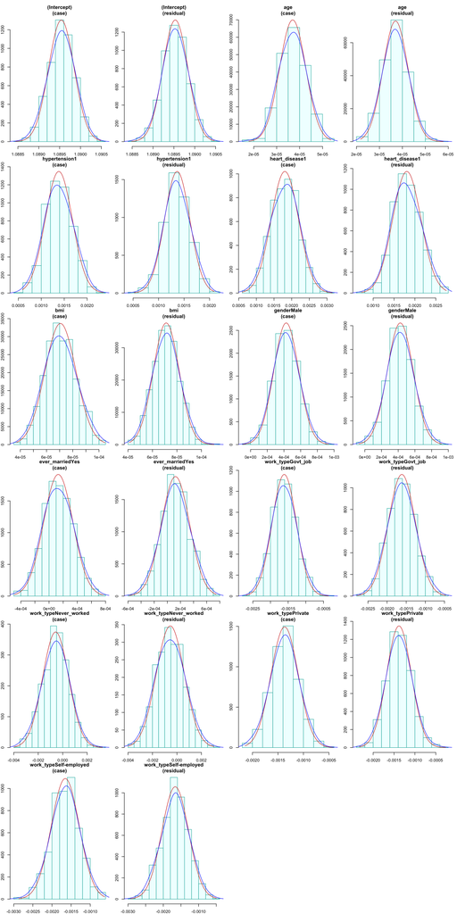

```r
boot.hist <- function(bt.coef.mtrx, var.id, var.nm, scheme) {
  x <- bt.coef.mtrx[, var.id]
  x <- x[is.finite(x)]

  if (length(x) < 2 || diff(range(x)) == 0) {
    plot.new()
    title(main = paste0(var.nm, "\n(", scheme, ": no finite values)"))
    return(invisible(NULL))
  }

  x1 <- seq(min(x), max(x), length = 300)
  y1 <- dnorm(x1, mean(x), sd(x))
  hb <- max(hist(x, plot = FALSE)$density)

  hist(x, probability = TRUE,
       main = paste0(var.nm, "\n(", scheme, ")"),
       xlab = "",
       col = "azure1",
       ylim = c(0, max(y1, hb)),
       border = "lightseagreen")
  lines(x1, y1, col = "red3")
  lines(density(x, adjust = 2), col = "blue")
}

#
par(mfrow = c(ceiling(num.p / 2), 4),
    mar = c(2, 2, 2, 1),
    oma = c(0, 0, 1, 0))

for (j in seq_len(num.p)) {
  boot.hist(btr_case, j, colnames(btr_case)[j], "case")
  boot.hist(btr_res,  j, colnames(btr_res)[j],  "residual")
}
```

We see here that both cases for the bootstrap methods show that the coefficients in the model are normal as you can see from the different graphs. With the our sample size being as large as it is the CLT is what causes these normal coefficients. We also see that the that the empirical and theoretical curves are relatively close showing that they are significant given the variables and p-values. ## Combined Bootstrap Summary

Here is where we will see a table that shows the differences between the bootstrap cases and bootstrap residuals and which of the non-parametric bootstraps is better for us to use. for these specific model.

```r
ols_fit  <- lm(glucose_bc ~ age + hypertension + heart_disease +
                 bmi + gender + ever_married + work_type,
               data = stroke_predictions_imp)
ols_coef <- summary(ols_fit)$coef

## Align rows to the design-matrix column order
Estimate   <- ols_coef[, "Estimate"]
Std.Error  <- ols_coef[, "Std. Error"]
p.value    <- ols_coef[, "Pr(>|t|)"]
Estimate   <- Estimate[colnames(X)]
Std.Error  <- Std.Error[colnames(X)]
p.value    <- p.value[colnames(X)]

btc.ci.95 <- apply(btr_case, 2, quantile, probs = c(0.025, 0.975))
btr.ci.95 <- apply(btr_res,  2, quantile, probs = c(0.025, 0.975))
fmt_ci <- function(lo, hi) {

    sig <- ifelse(lo > 0 | hi < 0, "*", " ")
  paste0("(", formatC(lo, format = "g", digits = 3),
         ", ", formatC(hi, format = "g", digits = 3), ")", sig)
}
coef_tbl <- data.frame(
  Estimate   = Estimate,
  Std.Error  = Std.Error,
  `Pr(>|t|)` = p.value,
  btc.ci.95  = fmt_ci(btc.ci.95[1, ], btc.ci.95[2, ]),
  btr.ci.95  = fmt_ci(btr.ci.95[1, ], btr.ci.95[2, ]),
  check.names = FALSE,
  row.names   = colnames(X)
)

kable(coef_tbl,
      digits  = c(5, 5, 5, NA, NA),
      align   = c("l", "r", "r", "c", "c"),
      caption = "Table 3. Regression coefficient matrix with OLS inference and 95% bootstrap percentile intervals")
```

Table 3. Regression coefficient matrix with OLS inference and 95% bootstrap percentile intervals

|  | Estimate | Std.Error | Pr(>\|t\|) | btc.ci.95 | btr.ci.95 |
| --- | --- | --- | --- | --- | --- |
| (Intercept) | 1.08954 | 0.00030 | 0.00000 | (1.09, 1.09)* | (1.09, 1.09)* |
| age | 0.00004 | 0.00001 | 0.00000 | (2.63e-05, 4.83e-05)* | (2.63e-05, 4.81e-05)* |
| hypertension1 | 0.00137 | 0.00026 | 0.00000 | (0.000802, 0.00197)* | (0.000889, 0.00184)* |
| heart_disease1 | 0.00179 | 0.00034 | 0.00000 | (0.00104, 0.00256)* | (0.00114, 0.0025)* |
| bmi | 0.00007 | 0.00001 | 0.00000 | (4.82e-05, 9.36e-05)* | (5.12e-05, 9.21e-05)* |
| genderMale | 0.00043 | 0.00015 | 0.00400 | (0.000144, 0.000724)* | (0.000112, 0.000725)* |
| ever_marriedYes | 0.00012 | 0.00022 | 0.56586 | (-0.000258, 0.00055) | (-0.000298, 0.000542) |
| work_typeGovt_job | -0.00162 | 0.00036 | 0.00001 | (-0.00228, -0.000899)* | (-0.00232, -0.000874)* |
| work_typeNever_worked | -0.00057 | 0.00113 | 0.61152 | (-0.00279, 0.00146) | (-0.00267, 0.0017) |
| work_typePrivate | -0.00138 | 0.00030 | 0.00000 | (-0.00193, -0.000863)* | (-0.00196, -0.000778)* |
| work_typeSelf-employed | -0.00166 | 0.00037 | 0.00001 | (-0.00241, -0.000934)* | (-0.00238, -0.00093)* |